## R 마크다운이란?

```r
summary(cars)
```

```
##      speed           dist
##  Min.   : 4.0   Min.   :  2.00
##  1st Qu.:12.0   1st Qu.: 26.00
##  Median :15.0   Median : 36.00
##  Mean   :15.4   Mean   : 42.98
##  3rd Qu.:19.0   3rd Qu.: 56.00
##  Max.   :25.0   Max.   :120.00
```

별도로 이미지 파일을 붙여 넣는 작업을 하지 않아도 코드 아래에 그래프를 삽입할 수 있습니다.

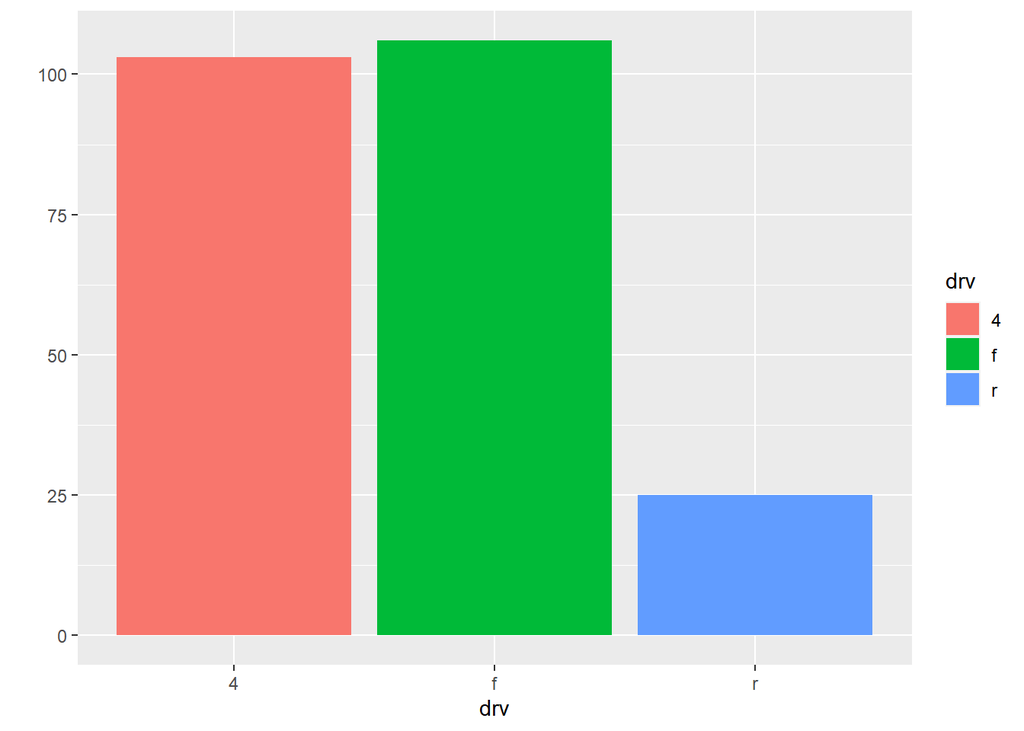

```r
library(ggplot2)
qplot(data = mpg, x = drv, fill = drv)
```

문자 앞뒤에 *특수 문자*를 넣으면 기울임체가 됩니다. 문자 앞뒤에 **특수 문자**를 넣으면 강조체가 됩니다. 문자 앞뒤에 특수 문자를 넣으면 취소선을 만듭니다.

문자 앞뒤에 [특수 문자](http://www.google.com/search?q=special+character)를 넣으면 하이퍼 링크를 만듭니다.

# 1 단계 제목

## 2 단계 제목

### 3 단계 제목

#### 4 단계 제목

데이터 앞부분 일부를 출력하려면 `head()` 를 이용하면 됩니다. `tail()`은 데이터 뒷부분 일부를 출력하는 기능을 합니다

코드 청크 라고 하며 단축키는 `Ctrl+Alt+I`

```r
summary(cars)
```

```
##      speed           dist
##  Min.   : 4.0   Min.   :  2.00
##  1st Qu.:12.0   1st Qu.: 26.00
##  Median :15.0   Median : 36.00
##  Mean   :15.4   Mean   : 42.98
##  3rd Qu.:19.0   3rd Qu.: 56.00
##  Max.   :25.0   Max.   :120.00
```

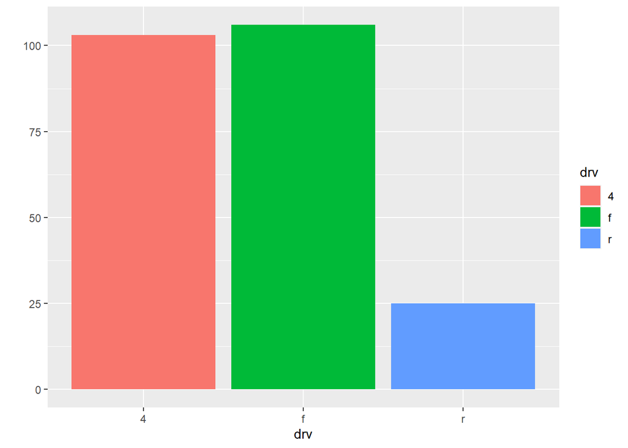

```r
library(ggplot2)
qplot(data = mpg, x = drv, fill = drv)
```

## [ ] 뒤에 공백 없이 이미지 경로를 괄호 ( ) 안에 입력

## 이미지 삽입

[figure not shown]

[figure not shown]

## 주석 처리

코드에는 기재되어 있으나, 출력 결과물에는 보이지 않음

위의 ‘주석 처리’는 보이지 않음

## 수평선 그리기

한 줄의 끝까지 선을 그림 *나 _를 3개 이상 입력

수평선 그리기